# Project1

Kumar Aiyer

01/15/2016

Load and transform the data for the analysis

```r
#{r setup, include=FALSE}
#opts_chunk$set(dev = 'pdf')

options(width=120)
#opts_chunk$set(dev = 'pdf')

#
# write a function geteloaddatadf() - you will assign the return value to eloaddf
# in the function do the following
# 1. load the electric load data from elecloaddata.xlsx
# you are not allowed to convert to .csv. Find an appropriate R package that can read .xlsx files and load
# the data in a dataframe called eloaddf. The columns should be dates, kwh, kwVAR
#
# some notes on the data
# the file has 15 min interval data from 1/1/2014 to 12/30/2015
# when you import the data, the first column of your data set should be dates in POSIXct format
# HINT: use the strptime and as.POSIX.ct functions to form the eloaddf$dates
#
# write a function getweatherdf() - you will assign the return value to weatherdf
# 2. Next load the weather data from NOAA into a data frame weatherdf. The data is in 1874606932872dat.txt
# This is 1 hour interval data for a specific weather station close to
# the location of the site from which electric load was obtained
#
# you need to use fixed width parsing to read the data into a data frame.
# add a column called dates to the dataframe similar to #1 above
#
# write a funcion getbillsdf() - you will assign the return value to billsdf
# 3. Next load the bill data from billdata.xlsx
# this data is monthly and carefully note the start and end date of each billing period.
# name the fields of the dataframe as
# billdate, billstartdt, billenddt, kwh, mindemandkw, actualdemandkw, custcharge,
# distchrgkw, mttkwh, tbckwh,nugckwh, sbckwh, rggieekwh, deliverykwh,
# totdeliverychrg, supplychrg, totalchrg
#
install_packages <- function(){

  if (!require("gplots")) {
     install.packages("gplots", dependencies = TRUE)
     library(gplots)
   }
   if (!require("RColorBrewer")) {
     install.packages("RColorBrewer", dependencies = TRUE)
     library(RColorBrewer)
   }

   if (!require("readxl")) {
       install.packages("readxl", dependencies = TRUE)
       library(readxl)
   }
   if (!require("openxlsx")) {
       install.packages("openxlsx", dependencies = TRUE)
       library(openxlsx)
   }
   if (!require("plyr")) {
       install.packages("plyr", dependencies = TRUE)
       library(plyr)
   }
   if (!require("gridExtra")) {
     install.packages("gridExtra", dependencies = TRUE)
     library(gridExtra)
   }
   if (!require("lubridate")) {
     install.packages("lubridate", dependencies = TRUE)
     library(lubridate)
   }
   if (!require("ggplot2")) {
     install.packages("ggplot2", dependencies = TRUE)
     library(ggplot2)
   }
   if (!require("caret")) {
     install.packages("caret", dependencies = TRUE)
     library(caret)
   }
   if (!require("gbm")) {
     install.packages("gbm", dependencies = TRUE)
     library(gbm)
   }
   if (!require("grid")) {
     install.packages("grid", dependencies = TRUE)
     library(grid)
   }
   if (!require("gridExtra")) {
     install.packages("gridExtra", dependencies = TRUE)
     library(gridExtra)
   }
   if (!require("cowplot")) {
     install.packages("cowplot", dependencies = TRUE)
     library(cowplot)
   }

}

geteloaddatadf <- function() {

   eloaddf <- read.xlsx("elecloaddata.xlsx", sheet = 1, colNames = TRUE)
   eloaddf$TIME <- sprintf("%04d", eloaddf$TIME)
   eloaddf$DATE <- sprintf("%06d", eloaddf$DATE)
   eloaddf$DATE <- as.POSIXct(paste(eloaddf$DATE, eloaddf$TIME), format="%m%d%y %H%M")
   #below I manually enter POSIX date conversions for 2AM daylight savings transition times that I found were showing up
   # as NAs in the data. R converted these 2 times as NA because of the daylight savings ambiguity.
   eloaddf$DATE[6440] <- as.POSIXct("2014-03-09 03:00:00")
   eloaddf$DATE[41384] <- as.POSIXct("2015-03-08 03:00:00")
   return(eloaddf)
}
getweatherdf <- function(){
   weatherdf <- read.fwf(file="1874606932872dat.txt",
     widths=(c(7, 6, 8,5, 4, 4, 4,4,4,2,2,2,5,3,3,3,3,3,3,3,3,2,5,5,7,6,7,4,4,6,6,6,6,3)))
     colnames(weatherdf) <- c("USAF","WBAN", "DATE","TIME", "DIR", "SPD", "GUS", "CLG", "SKC", "L", "M", "H", "VSB", "MW",      "MW", "MW", "MW", "AW", "AW", "AW", "AW", "W", "TEMP", "DEWP","SLP",  "ALT", "STP", "MAX", "MIN", "PCP01", "PCP06",
     "PCP24", "PCP25", "PCP26")
   weatherdf <- weatherdf[-c(1), ]
   weatherdf$TIME <- sprintf("%04s", weatherdf$TIME)
   weatherdf$DATE = as.POSIXct(as.character(paste(weatherdf$DATE, weatherdf$TIME)), format='%Y%m%d %H%M')
   weatherdf$TIME <- NULL
   weatherdf$TEMP <-  as.numeric(as.character(weatherdf$TEMP))
   return(weatherdf)
}


install_packages()
```

Now, load the electric load datat (eloaddf) and print out the first 20 rows to make sure it loads correctly

```r
options(width=120)
eloaddf <- geteloaddatadf()  # get the electric load data
print(head(eloaddf, 20))  # plot the first 20 rows of load data
```

```
##                   DATE TIME    kWh  kVARh
## 1  2014-01-01 00:15:00 0015 81.384 72.912
## 2  2014-01-01 00:30:00 0030 94.608 89.136
## 3  2014-01-01 00:45:00 0045 76.968 69.696
## 4  2014-01-01 01:00:00 0100 90.048 82.968
## 5  2014-01-01 01:15:00 0115 69.384 61.104
## 6  2014-01-01 01:30:00 0130 97.536 91.992
## 7  2014-01-01 01:45:00 0145 77.928 71.136
## 8  2014-01-01 02:00:00 0200 90.744 83.784
## 9  2014-01-01 02:15:00 0215 82.824 73.752
## 10 2014-01-01 02:30:00 0230 83.304 73.512
## 11 2014-01-01 02:45:00 0245 78.984 69.288
## 12 2014-01-01 03:00:00 0300 79.128 70.992
## 13 2014-01-01 03:15:00 0315 80.880 72.912
## 14 2014-01-01 03:30:00 0330 79.440 70.032
## 15 2014-01-01 03:45:00 0345 78.624 70.272
## 16 2014-01-01 04:00:00 0400 82.152 74.496
## 17 2014-01-01 04:15:00 0415 78.432 69.576
## 18 2014-01-01 04:30:00 0430 71.064 61.440
## 19 2014-01-01 04:45:00 0445 73.488 64.632
## 20 2014-01-01 05:00:00 0500 75.072 65.328
```

```r
print("Electric load data last rows:\n")
```

```
## [1] "Electric load data last rows:\n"
```

```r
print(tail(eloaddf, 20))
```

```
##                      DATE TIME     kWh   kVARh
## 69965 2015-12-30 19:15:00 1915 146.856 113.928
## 69966 2015-12-30 19:30:00 1930 156.840 122.928
## 69967 2015-12-30 19:45:00 1945 155.592 123.360
## 69968 2015-12-30 20:00:00 2000 158.928 125.688
## 69969 2015-12-30 20:15:00 2015 163.800 132.240
## 69970 2015-12-30 20:30:00 2030 160.776 128.688
## 69971 2015-12-30 20:45:00 2045 165.024 132.360
## 69972 2015-12-30 21:00:00 2100 158.928 127.896
## 69973 2015-12-30 21:15:00 2115 165.672 133.176
## 69974 2015-12-30 21:30:00 2130 160.104 128.928
## 69975 2015-12-30 21:45:00 2145 156.816 121.344
## 69976 2015-12-30 22:00:00 2200 164.184 131.472
## 69977 2015-12-30 22:15:00 2215 168.336 132.672
## 69978 2015-12-30 22:30:00 2230 167.064 136.104
## 69979 2015-12-30 22:45:00 2245 148.320 116.688
## 69980 2015-12-30 23:00:00 2300 143.136 120.096
## 69981 2015-12-30 23:15:00 2315 117.552 103.104
## 69982 2015-12-30 23:30:00 2330  79.416  63.432
## 69983 2015-12-30 23:45:00 2345  71.544  54.720
## 69984 2015-12-31 00:00:00 2400  74.304  57.504
```

Also, print out the last 20 rows of load data to make sure it is also correct

```r
options(width=120)

print(tail(eloaddf, 20)) #printing the last 20 rows
```

```
##                      DATE TIME     kWh   kVARh
## 69965 2015-12-30 19:15:00 1915 146.856 113.928
## 69966 2015-12-30 19:30:00 1930 156.840 122.928
## 69967 2015-12-30 19:45:00 1945 155.592 123.360
## 69968 2015-12-30 20:00:00 2000 158.928 125.688
## 69969 2015-12-30 20:15:00 2015 163.800 132.240
## 69970 2015-12-30 20:30:00 2030 160.776 128.688
## 69971 2015-12-30 20:45:00 2045 165.024 132.360
## 69972 2015-12-30 21:00:00 2100 158.928 127.896
## 69973 2015-12-30 21:15:00 2115 165.672 133.176
## 69974 2015-12-30 21:30:00 2130 160.104 128.928
## 69975 2015-12-30 21:45:00 2145 156.816 121.344
## 69976 2015-12-30 22:00:00 2200 164.184 131.472
## 69977 2015-12-30 22:15:00 2215 168.336 132.672
## 69978 2015-12-30 22:30:00 2230 167.064 136.104
## 69979 2015-12-30 22:45:00 2245 148.320 116.688
## 69980 2015-12-30 23:00:00 2300 143.136 120.096
## 69981 2015-12-30 23:15:00 2315 117.552 103.104
## 69982 2015-12-30 23:30:00 2330  79.416  63.432
## 69983 2015-12-30 23:45:00 2345  71.544  54.720
## 69984 2015-12-31 00:00:00 2400  74.304  57.504
```

Now, load the weather data and print out the first 10 rows to make sure it loads correctly

```r
options(width=120)
weatherdf <- getweatherdf() # load the weatherdata
print(head(weatherdf,10)) # print the first 10 rows of the weather data
```

```
##       USAF   WBAN                DATE  DIR  SPD  GUS  CLG  SKC  L  M  H   VSB  MW  MW  MW  MW  AW  AW  AW  AW  W TEMP
## 2  724075  13735  2014-01-01 00:54:00 300    8  ***  722  CLR  *  *  *  10.0  **  **  **  **  **  **  **  **  *    33
## 3  724075  13735  2014-01-01 01:54:00 300    9  ***  722  CLR  *  *  *  10.0  **  **  **  **  **  **  **  **  *    31
## 4  724075  13735  2014-01-01 02:54:00 310    6  ***  722  CLR  *  *  *  10.0  **  **  **  **  **  **  **  **  *    29
## 5  724075  13735  2014-01-01 03:54:00 ***    0  ***  722  CLR  *  *  *  10.0  **  **  **  **  **  **  **  **  *    23
## 6  724075  13735  2014-01-01 04:54:00 ***    0  ***  722  CLR  *  *  *  10.0  **  **  **  **  **  **  **  **  *    23
## 7  724075  13735  2014-01-01 04:59:00 ***  ***  ***  ***  ***  *  *  *  ****  **  **  **  **  **  **  **  **  *    NA
## 8  724075  13735  2014-01-01 05:54:00 270    3  ***  722  CLR  *  *  *  10.0  **  **  **  **  **  **  **  **  *    21
## 9  724075  13735  2014-01-01 06:54:00 ***    0  ***  722  CLR  *  *  *  10.0  **  **  **  **  **  **  **  **  *    22
## 10 724075  13735  2014-01-01 07:54:00 ***    0  ***  722  CLR  *  *  *  10.0  **  **  **  **  **  **  **  **  *    20
## 11 724075  13735  2014-01-01 08:54:00 020    3  ***  722  CLR  *  *  *  10.0  **  **  **  **  **  **  **  **  *    21
##     DEWP     SLP    ALT     STP  MAX  MIN  PCP01  PCP06  PCP24  PCP25 PCP26
## 2    16  1024.9  30.27  1022.3  ***  ***   0.00  *****  *****  *****    **
## 3    16  1025.5  30.29  1022.9  ***  ***   0.00  *****  *****  *****    **
## 4    16  1026.1  30.30  1023.3  ***  ***   0.00  *****  *****  *****    **
## 5    18  1026.8  30.32  1024.0  ***  ***   0.00  *****  *****  *****    **
## 6    17  1027.2  30.34  1024.6   41   22   0.00  *****  *****  *****    **
## 7  ****  ******  *****  ******   41  ***  *****  *****   0.00  *****    **
## 8    18  1027.7  30.35  1025.0   35   21   0.00  *****  *****  *****    **
## 9    19  1028.6  30.38  1026.0  ***  ***   0.00  *****  *****  *****    **
## 10   17  1029.0  30.39  1026.3  ***  ***   0.00  *****  *****  *****    **
## 11   17  1028.7  30.38  1026.0  ***  ***   0.00  *****  *****  *****    **
```

… and print out the last 10 rows of the weather data to check the end of the load

```r
options(width=120)
print(tail(weatherdf,10)) ## print the last 10 rows of weather data
```

```
##          USAF   WBAN                DATE  DIR  SPD  GUS  CLG  SKC  L  M  H   VSB  MW  MW  MW  MW  AW  AW  AW  AW  W
## 19168 724075  13735  2016-01-01 14:54:00 310    8  ***  722  CLR  *  *  *  10.0  **  **  **  **  **  **  **  **  *
## 19169 724075  13735  2016-01-01 15:54:00 290   11  ***  722  CLR  *  *  *  10.0  **  **  **  **  **  **  **  **  *
## 19170 724075  13735  2016-01-01 16:54:00 280   10  ***   28  ***  *  *  *  10.0  **  **  **  **  **  **  **  **  *
## 19171 724075  13735  2016-01-01 17:54:00 270   15   23  722  SCT  *  *  *  10.0  **  **  **  **  **  **  **  **  *
## 19172 724075  13735  2016-01-01 18:54:00 300   15   23   36  ***  *  *  *  10.0  **  **  **  **  **  **  **  **  *
## 19173 724075  13735  2016-01-01 19:54:00 300   11  ***   40  ***  *  *  *  10.0  **  **  **  **  **  **  **  **  *
## 19174 724075  13735  2016-01-01 20:54:00 300    8  ***   46  ***  *  *  *  10.0  **  **  **  **  **  **  **  **  *
## 19175 724075  13735  2016-01-01 21:54:00 310    5  ***  722  CLR  *  *  *  10.0  **  **  **  **  **  **  **  **  *
## 19176 724075  13735  2016-01-01 22:54:00 290    9  ***   48  ***  *  *  *  10.0  **  **  **  **  **  **  **  **  *
## 19177 724075  13735  2016-01-01 23:54:00 290   11  ***   50  ***  *  *  *  10.0  **  **  **  **  **  **  **  **  *
##       TEMP  DEWP     SLP    ALT     STP  MAX  MIN  PCP01  PCP06  PCP24  PCP25 PCP26
## 19168   41   31  1019.9  30.12  1017.2  ***  ***   0.00  *****  *****  *****    **
## 19169   42   30  1019.2  30.10  1016.5  ***  ***   0.00  *****  *****  *****    **
## 19170   43   31  1018.7  30.08  1015.9  ***  ***   0.00  *****  *****  *****    **
## 19171   43   30  1017.7  30.06  1015.2   44   37   0.00  *****  *****  *****    **
## 19172   42   28  1017.3  30.04  1014.5  ***  ***   0.00  *****  *****  *****    **
## 19173   42   28  1017.2  30.04  1014.5  ***  ***   0.00  *****  *****  *****    **
## 19174   41   28  1017.4  30.05  1014.8  ***  ***   0.00  *****  *****  *****    **
## 19175   39   27  1017.6  30.05  1014.8  ***  ***   0.00  *****  *****  *****    **
## 19176   39   27  1018.0  30.06  1015.2  ***  ***   0.00  *****  *****  *****    **
## 19177   39   25  1018.7  30.08  1015.9   44   36   0.00  *****  *****  *****    **
```

OK, everything seems correct so far.

…now I will load the billing data. I will print it as part of a later step.

```r
billdf <- read_excel("billdata.xlsx", sheet=1)
colnames(billdf) <- c("billdate", "billstartdt", "billenddt", "kwh", "mindemandkw", "actualdemandkw", "custcharge",
                      "distchrgkw", "mttkwh", "tbckwh","nugckwh", "sbckwh", "rggieekwh", "deliverykwh",
                      "totdeliverychrg", "supplychrg", "totalchrg")
billdf <- head(billdf, -1)
```

```r
# We now have 3 data sets

#1. Electric load data in 15 min interval
#2. Weather data in 60 min interval
#3. Bill data monthly

#Lets do some simple analysis

#Display the monthly load profile

print(billdf)
```

```
##      billdate billstartdt  billenddt   kwh mindemandkw actualdemandkw custcharge distchrgkw    mttkwh    tbckwh
## 1  2015-01-01  2014-12-20 2015-01-28 66460      140.48          130.2     175.15  10.213340 0.0043541 0.0067019
## 2  2015-02-01  2015-01-29 2015-02-26 41180      140.48          107.6     126.98   7.404784 0.0043541 0.0067019
## 3  2015-03-01  2015-02-27 2015-03-27 48860      140.48          139.4     126.98   7.404684 0.0043541 0.0067019
## 4  2015-04-01  2015-03-28 2015-04-28 65360      140.48           96.0     140.12   8.170701 0.0043541 0.0067019
## 5  2015-05-01  2015-04-29 2015-05-27 70020      140.48           24.4     126.98   7.404684 0.0043541 0.0067019
## 6  2015-06-01  2015-05-28 2015-06-26 86500      140.48          172.4     131.36   7.659977 0.0043541 0.0067019
## 7  2015-07-01  2015-06-27 2015-07-30 88500      140.48          159.2     148.87   8.681344 0.0043541 0.0067019
## 8  2015-08-01  2015-07-31 2015-08-28 80240      137.92          171.0     126.98   7.404780 0.0043541 0.0067019
## 9  2015-09-01  2015-08-29 2015-09-28 81160      137.92          168.0     135.74   7.915357 0.0043541 0.0067019
## 10 2015-10-01  2015-09-29 2015-10-28 73760      137.92          163.0     131.36   7.660000 0.0031841 0.0067897
## 11 2015-11-01  2015-10-29 2015-11-25 65740      137.92          160.8     122.60   7.149316 0.0031010 0.0067960
## 12 2015-12-01  2015-11-26 2015-12-29 64160      137.92          136.6     148.87   8.681337 0.0031010 0.0067960
##      nugckwh    sbckwh rggieekwh deliverykwh totdeliverychrg supplychrg totalchrg
## 1  0.0122340 0.0082850 0.0006199   0.0321949        3749.593   6140.904  9890.497
## 2  0.0122340 0.0082850 0.0006199   0.0321949        2492.990   3805.032  6298.022
## 3  0.0122340 0.0082850 0.0006199   0.0321949        2740.233   4514.664  7254.897
## 4  0.0122340 0.0082850 0.0006199   0.0321949        3392.199   6039.264  9431.463
## 5  0.0122340 0.0082850 0.0006199   0.0321949        3421.477   6469.848  9891.325
## 6  0.0156155 0.0081775 0.0006199   0.0354689        4520.000   7923.400 12443.400
## 7  0.0161350 0.0081610 0.0006101   0.0359621        4713.586   6893.800 11607.386
## 8  0.0161350 0.0081610 0.0006199   0.0359719        4279.583   6250.370 10529.953
## 9  0.0161350 0.0081610 0.0006199   0.0359719        4384.999   6322.040 10707.039
## 10 0.0161350 0.0083712 0.0006100   0.0350900        3968.178   5745.610  9713.788
## 11 0.0161349 0.0083859 0.0006100   0.0350278        3574.938   5120.880  8695.818
## 12 0.0161349 0.0083861 0.0007927   0.0352107        3605.319   4997.810  8603.129
```

```r
#display a summary of the electric load data eloaddf$kwh by summarizing it by year, month and total kwh over each month
# your answer should display 24 rows without the header.

eloaddf$MONTHYR <- strftime(eloaddf$DATE, format="%Y/%m")
monthsum <- ddply(eloaddf, .(MONTHYR), summarize, monthlyKWH=sum(kWh))
print(monthsum)
```

```
##    MONTHYR monthlyKWH
## 1  2014/01   309948.8
## 2  2014/02   290162.1
## 3  2014/03   300137.5
## 4  2014/04   377233.9
## 5  2014/05   414294.4
## 6  2014/06   429505.4
## 7  2014/07   436259.5
## 8  2014/08   442236.7
## 9  2014/09   435527.3
## 10 2014/10   477017.8
## 11 2014/11   369653.2
## 12 2014/12   341987.8
## 13 2015/01   309988.8
## 14 2015/02   276804.4
## 15 2015/03   331322.5
## 16 2015/04   360325.9
## 17 2015/05   400992.0
## 18 2015/06   395680.7
## 19 2015/07   408545.7
## 20 2015/08   427463.4
## 21 2015/09   405048.4
## 22 2015/10   494114.2
## 23 2015/11   443282.9
## 24 2015/12   365085.6
```

Now let us do some plotting of the load data

```r
# form a dataframe called eloadhrdf with two columns dates, kwh
# this data frame sums the 15min kwh in the eloaddf to hourly data

eloadhrdf <- data.frame(kwh = eloaddf$kWh, dates = round(as.POSIXct(eloaddf$DATE, format="%Y%m%d %H:M"),"hours"))
eloadhrdf <- ddply(eloadhrdf, .(dates), summarize, kwh = sum(kwh))
print(head(eloadhrdf,30))
```

```
##                  dates     kwh
## 1  2014-01-01 00:00:00  81.384
## 2  2014-01-01 01:00:00 331.008
## 3  2014-01-01 02:00:00 349.032
## 4  2014-01-01 03:00:00 322.296
## 5  2014-01-01 04:00:00 318.648
## 6  2014-01-01 05:00:00 301.008
## 7  2014-01-01 06:00:00 328.248
## 8  2014-01-01 07:00:00 321.384
## 9  2014-01-01 08:00:00 322.152
## 10 2014-01-01 09:00:00 324.864
## 11 2014-01-01 10:00:00 333.888
## 12 2014-01-01 11:00:00 319.992
## 13 2014-01-01 12:00:00 319.872
## 14 2014-01-01 13:00:00 343.536
```

[output cut: 16 more lines]

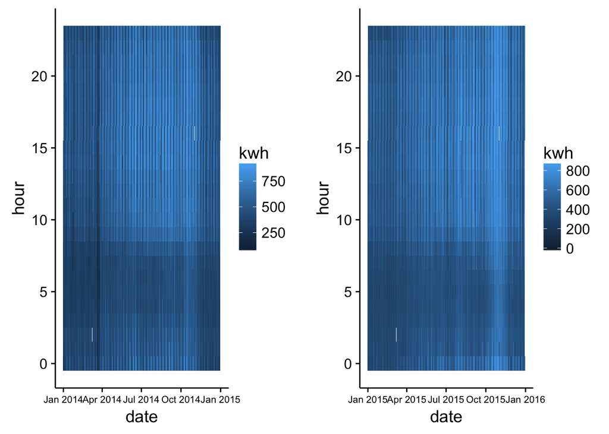

```r
# # next create a plot frame with two panels side by side
# On the left panel show a heat map of kwh data for 2014 with x-axis as months and y-axis as hour of the day (1 to 24). #use subsetting of the data frame rather than copying the data into yet another data frame
# On the right panel show a heat map of kwh data for 2015 with x-axis as months and y-axis as hour of the day (1 to 24). use subsetting of the data frame rather than copying the data into yet another data frame

eloadhrdf14 <- subset(eloadhrdf, year(eloadhrdf$date) == 2014)
eloadhrdf14$hour <- hour(eloadhrdf14$date)
eloadhrdf14$date <- as.Date(eloadhrdf14$date, format = "%y/%m/%d")
eloadhrdf15 <- subset(eloadhrdf, year(eloadhrdf$date) == 2015)
eloadhrdf15$hour <- hour(eloadhrdf15$date)
eloadhrdf15$date <- as.Date(eloadhrdf15$date, format = "%y/%m/%d")

heat14 <- ggplot(eloadhrdf14, aes(x=date, y=hour), main="2014 Heatmap") + geom_tile(aes(fill=kwh)) + theme(axis.text.x = element_text(size=8))

heat15 <- ggplot(eloadhrdf15, aes(x=date, y=hour), main="2015 Heatmap") + geom_tile(aes(fill=kwh)) + theme(axis.text.x = element_text(size=8))

grid.arrange(heat14,heat15, ncol=2)
```

Comments on the data:

Based on the amount of power being used and the patterns in the data, it appears that the consumer involved is an office building, group of office buildings, school, or some other large entity - as opposed to a household or small business. For example, by studying both heatmaps, it is easy to see thin black vertical lines at evenly spaced intervals. These lines appear consistently accross each plot. It seems likely that these lines are associated with weekends, when most buildings use much less power at all times of the day. Similarly, a dark area on both heatmaps reveals that on all days of the year, the power usage is relatively low between the hours of 2:30AM and 7:00AM. At 7:00AM begins a roughly 30-60 minute period of more moderate energy use, followed by relatively high energy use starting at 9:00AM and lasting until 10:00PM, when energy use tends to taper off before bottoming out around 2:30. This is very consistent with energy usage profile of a large office building, in which heating or cooling of the building is best done gradually, beginning 1-2 hours before most people show up for work.

In the 2014 heatmap, it is possible to see a dark vertical band at the far right of the plot, in a position corresponding to the month of December, 2014. The darkness indicates consistent low power usage, and this would seem to suggest that the entity being studied is a school, since most schools are closed in December. Similarly, there is another dark vertical band visible in the 2014 plot. This band is narrower and corresponds to approximately March 20-25, 2014. If indeed the entity was a school, the short period of consistently low power usage may have been a result of the school being closed for a spring holiday week, which tend to be in late March in most school districts. However, the March and December periods of low energy use that are visible in 2014 are much less recognizable, if not entirely nonexistent, in the 2015 data and heatmap.

There are quite a few other conclusions that can be made from the data. For example, it seems likely that the entity uses more power for cooling than heating, since the heatmap shows that summer months are associated with higher energy use than winter months, in general. Additionally, the weather data indicates that the geographic location being studied does not have a severe climate, but is somewhere that probably receives snowfall. For example, the following is a summary of the 2014 and 2015 temeperature data.

Min. 1st Qu. Median Mean 3rd Qu. Max. NA’s -7.00 40.00 57.00 54.39 70.00 94.00 1023

This range of temperatures makes me expect that the weather data was registered in a place like Denver, Salt Lake City or Reno.

======================================================================================================================

We plot the weather data using boxplot to explore the variation in temperature graphically

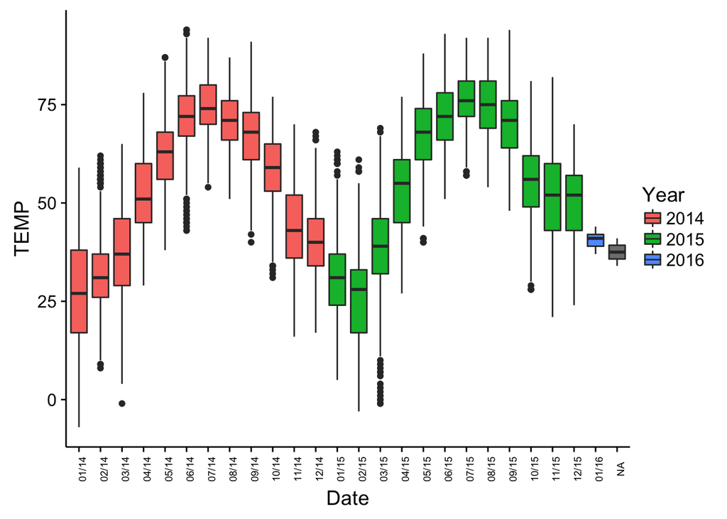

```r
# plot the weather data. Use boxplots in ggplot2 with month on the x-axis and temperature in y-axis
 dt <- ggplot(weatherdf) + geom_boxplot(aes(y=TEMP,x=reorder(format(weatherdf$DATE,'%m/%y'),weatherdf$DATE),
                                            fill=format(weatherdf$DATE,'%Y'))) +
   xlab('Date') + guides(fill=guide_legend(title="Year")) + theme(axis.text.x = element_text(size=7, angle = 90))
 print(dt)
```

We are now ready to build a simple predictive model.

```r
#create a dataframe with hourly interval data inside your function by
# combining selective columns from eloadhrdf and weatherdf
# your dataframe should be called  and the columns should be dates, year, month, hrofday, temp, kwh

# First, I have to manipulate the weatherdf data format to do an inner joing (merge) with eloadhrdf dataframe
weatherdf$roundDATE <- as.POSIXct(round(weatherdf$DATE, "hours"),format='%Y%m%d %H:%M')
weatherdf_filtered <- subset(weatherdf, select = c("DATE", "TEMP", "roundDATE"))
# Now, I merge eloadhrdf and weatherdf using an inner join
modeldatadf <- merge(eloadhrdf,weatherdf_filtered,by.x="dates", by.y="roundDATE")
modeldatadf <- cbind(modeldatadf, year = year(modeldatadf$dates), month = month(modeldatadf$dates), hrofday =                    hour(modeldatadf$dates)) #  incorporating columns specifically for hour of day and month
modeldatadf$DATE <- NULL # the inner join left 2 date columns, so this eliminates the redundant column
modeldatadf <- modeldatadf[complete.cases(modeldatadf$TEMP),]  #deletes rows having missing temperature data
```

This is the first and last 20 rows of modeldatadf

```r
print(head(modeldatadf,20))
```

```
##                  dates     kwh TEMP year month hrofday
## 1  2014-01-01 01:00:00 331.008   33 2014     1       1
## 2  2014-01-01 02:00:00 349.032   31 2014     1       2
## 3  2014-01-01 03:00:00 322.296   29 2014     1       3
## 4  2014-01-01 04:00:00 318.648   23 2014     1       4
## 6  2014-01-01 05:00:00 301.008   23 2014     1       5
## 7  2014-01-01 06:00:00 328.248   21 2014     1       6
## 8  2014-01-01 07:00:00 321.384   22 2014     1       7
## 9  2014-01-01 08:00:00 322.152   20 2014     1       8
## 10 2014-01-01 09:00:00 324.864   21 2014     1       9
## 11 2014-01-01 10:00:00 333.888   20 2014     1      10
## 12 2014-01-01 11:00:00 319.992   24 2014     1      11
## 13 2014-01-01 12:00:00 319.872   24 2014     1      12
## 14 2014-01-01 13:00:00 343.536   24 2014     1      13
## 15 2014-01-01 14:00:00 370.248   29 2014     1      14
## 16 2014-01-01 15:00:00 346.680   36 2014     1      15
## 17 2014-01-01 16:00:00 350.544   39 2014     1      16
## 18 2014-01-01 17:00:00 343.080   40 2014     1      17
## 19 2014-01-01 18:00:00 346.176   41 2014     1      18
## 20 2014-01-01 19:00:00 323.424   40 2014     1      19
## 21 2014-01-01 20:00:00 370.080   41 2014     1      20
```

```r
print(tail(modeldatadf, 20))
```

```
##                     dates     kwh TEMP year month hrofday
## 19122 2015-12-30 04:00:00 369.672   51 2015    12       4
## 19123 2015-12-30 05:00:00 348.816   50 2015    12       5
## 19125 2015-12-30 06:00:00 390.600   49 2015    12       6
## 19126 2015-12-30 07:00:00 469.440   46 2015    12       7
## 19127 2015-12-30 08:00:00 562.776   45 2015    12       8
## 19128 2015-12-30 08:00:00 562.776   43 2015    12       8
## 19129 2015-12-30 08:00:00 562.776   44 2015    12       8
## 19130 2015-12-30 09:00:00 597.168   46 2015    12       9
## 19131 2015-12-30 10:00:00 626.664   46 2015    12      10
## 19132 2015-12-30 11:00:00 599.616   46 2015    12      11
## 19133 2015-12-30 12:00:00 597.936   46 2015    12      12
## 19134 2015-12-30 13:00:00 572.088   46 2015    12      13
## 19135 2015-12-30 14:00:00 631.080   47 2015    12      14
## 19136 2015-12-30 15:00:00 638.328   49 2015    12      15
## 19137 2015-12-30 16:00:00 616.032   50 2015    12      16
## 19138 2015-12-30 17:00:00 609.984   52 2015    12      17
## 19139 2015-12-30 18:00:00 649.176   53 2015    12      18
## 19140 2015-12-30 19:00:00 598.968   53 2015    12      19
## 19141 2015-12-30 20:00:00 635.160   53 2015    12      20
## 19142 2015-12-30 21:00:00 650.400   52 2015    12      21
```

… OK that data looks good

```r
# write a simple function called predmodel. the model object should be the return parameter
# pass in the appropriate data frames.
# you should fit a GLM with the following specification kwh ~ month + hrofday + temp
# your model should only use 2014 data for your prediction model use the summary function and display the results of the
# function
predmodel <- function() {
  regression <- lm(kwh ~ month + hrofday + TEMP, subset(modeldatadf, year == 2014))
  return(regression)
}

regression <- predmodel()
print(summary(regression))
```

```
##
## Call:
## lm(formula = kwh ~ month + hrofday + TEMP, data = subset(modeldatadf,
##     year == 2014))
##
## Residuals:
##     Min      1Q  Median      3Q     Max
## -384.49  -87.10    7.52   93.32  332.55
##
## Coefficients:
##              Estimate Std. Error t value Pr(>|t|)
## (Intercept) 218.98349    4.25771   51.43   <2e-16 ***
## month         5.61930    0.37963   14.80   <2e-16 ***
## hrofday       6.90799    0.18500   37.34   <2e-16 ***
## TEMP          3.64171    0.07175   50.75   <2e-16 ***
## ---
## Signif. codes:  0 '***' 0.001 '**' 0.01 '*' 0.05 '.' 0.1 ' ' 1
##
## Residual standard error: 118.9 on 9046 degrees of freedom
## Multiple R-squared:  0.3987, Adjusted R-squared:  0.3985
## F-statistic:  1999 on 3 and 9046 DF,  p-value: < 2.2e-16
```

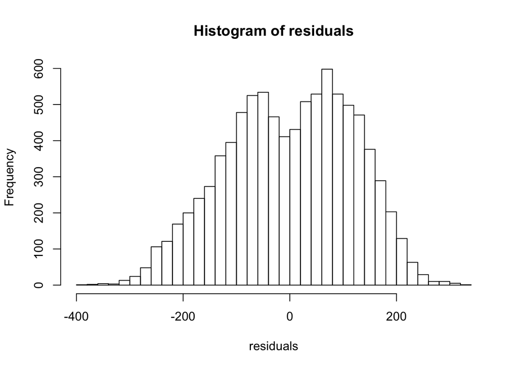

```r
residuals <- resid(regression)
hist(residuals,50)
```

Inference about the regression model.

In general, this model is very simple and conservative but lacks explanatory power. As shown in the summary above, the model has R^2=.39, meaning that 39% of the variance in the kWh data can be explained by the model.

```r
simple_model_error = mean(abs(modeldatadf$kwh-mean(modeldatadf$kwh)))
cat("This is average error magnitude of the simple model : ", simple_model_error)
```

```
## This is average error magnitude of the simple model :  129.8264
```

```r
regression_model_error = mean(abs(residuals))
cat("This is the average error magnitude of the 3-variable regression model", regression_model_error)
```

```
## This is the average error magnitude of the 3-variable regression model 99.74377
```

The weaknesses of the model can be grasped intuitively. As a linear regression model, the model is premised on certain assumptions about the data that clearly do not hold in the case of this data. For example, linear regression assumes that the target variable (kwh in this case) is a linear function of each covariate. But electricity consumption is clearly not a linear function of hour of the day. Rather, on just about any day in the data set, regardless of month or temperature changes, electrical consumption is minimal and roughly unchanged throughout the middle of the night and early morning hours. It then spikes quickly around 9-10AM and drops dramatically late at night. Clearly, this pattern is affected by temperature, but largely driven by the waking and sleeping patterns of people, and building occupancy patterns, which are related most strongly to time of day. So, it stands to reason that the linear relationship between electricity use and hour of day is not too strong. The same is true with regards to the other 2 covariates.

The lack of linear relationship between electricity usage and the temperature covariate (as one example) can be seen by taking a slice of the data for which the month and hour of day values are constant, and then measuring the correlation between temperature and kwh for the slice. This is a measure of covariance over a small subsample (only 30 rows) of the data, but the results are illustrative of the lack of linear relationship. Looking at the 12:00 nooon observations during the month of September, the covariance between kwh and temperature is:

```r
const_m_h <- modeldatadf[with(modeldatadf, year == 2014 & month == 9 & hrofday == 12), ]
print(cor(subset(const_m_h, select = c("TEMP", "kwh"))))
```

```
##           TEMP       kwh
## TEMP 1.0000000 0.2407883
## kwh  0.2407883 1.0000000
```

In other words, almost no linear relationship within this subsample.

Looking at another subsample now - for June at 6PM:

```r
const_m_h <- modeldatadf[with(modeldatadf, year == 2014 & month == 6 & hrofday == 18), ]
print(cor(subset(const_m_h, select = c("TEMP", "kwh"))))
```

```
##           TEMP       kwh
## TEMP 1.0000000 0.3987446
## kwh  0.3987446 1.0000000
```

… and for March at 5AM:

```r
const_m_h <- modeldatadf[with(modeldatadf, year == 2014 & month == 3 & hrofday == 5), ]
print(cor(subset(const_m_h, select = c("TEMP", "kwh"))))
```

```
##            TEMP        kwh
## TEMP 1.00000000 0.06762483
## kwh  0.06762483 1.00000000
```

So, by rough inspection it seems that the strength of the linear relationship between temperature and energy usage is minimal.

Now, observing the covariance matrix across the entire 2014 data set, temperature is the covariate that is most correlated with kWh.

```r
print(cor(subset(modeldatadf[with(modeldatadf, year == 2014), ], select = c("TEMP", "month", "hrofday", "kwh"))))
```

```
##              TEMP        month      hrofday       kwh
## TEMP    1.0000000 0.3104277606 0.1923867240 0.5437764
## month   0.3104278 1.0000000000 0.0005504995 0.2653613
## hrofday 0.1923867 0.0005504995 1.0000000000 0.3964392
## kwh     0.5437764 0.2653612874 0.3964391802 1.0000000
```

Thus, I would expect temperature to have more explanatory power than any of the other covariates. Indeed, as can be seen in the regression summary below, the t-statistic for temperature is higher than for the other covariates. Thus, of the three covariates, temperature has the highest likelihood of being non-zero in the true distribution.

In addition to the assumption of a linear relationship between predictors and the target variable, linear regression assumes that noise in the data is Gaussian. The histogram of the residuals (plotted above) shows that this is not the case. As a result, statistical inference about the significance of the model covariates will be biased.

It is possible to test the hypothesis that this model is actually no better than a model which simply uses the sample average as the estimator of electric usage in all cases. In other words, this is a test of a null hypothesis that none of the covariates have any explanatory power in the model. This is done using the F-test. The F-test results for the regression model are shown in the following underlined portion of the regression summary in R:

```r
summary(regression)
```

```
##
## Call:
## lm(formula = kwh ~ month + hrofday + TEMP, data = subset(modeldatadf,
##     year == 2014))
##
## Residuals:
##     Min      1Q  Median      3Q     Max
## -384.49  -87.10    7.52   93.32  332.55
##
## Coefficients:
##              Estimate Std. Error t value Pr(>|t|)
## (Intercept) 218.98349    4.25771   51.43   <2e-16 ***
## month         5.61930    0.37963   14.80   <2e-16 ***
## hrofday       6.90799    0.18500   37.34   <2e-16 ***
## TEMP          3.64171    0.07175   50.75   <2e-16 ***
## ---
## Signif. codes:  0 '***' 0.001 '**' 0.01 '*' 0.05 '.' 0.1 ' ' 1
##
## Residual standard error: 118.9 on 9046 degrees of freedom
## Multiple R-squared:  0.3987, Adjusted R-squared:  0.3985
## F-statistic:  1999 on 3 and 9046 DF,  p-value: < 2.2e-16
```

The very low p-value associated with the F-test indicates that we can reject this null hypothesis and accept the alternative hypothesis that at least one of the covariates is useful in predicting kWh. We should understand, however, that the F-test is biased as a result of the residuals not being distributed as Gaussian. There may be further bias in this test if the residuals are correlated with each other and/or heteroskedastic, but I will not test for these deficiencies.

We can also test whether any one of the individual predictors could be dropped from the model without detriment to the model’s predictive value. In this test, for each predictor, the null hypothesis is that dropping the predictor from the model while keeping the other two predictors would not reduce the predictive value . However, each of the 3 predictors has a p-value well below .01 in the summary table above. Accordingly, it is appropriate to fail to accept the null hypothesis in the case of each predictor. Thus, I expect that the model fitted with 3 covariates would predict better than any other first order linear regression having only 2 of the 3 predictors.

Now show you skills in Machine Learning!

```r
# use the dataframe modeldatadf
# split it into training and testing data sets based on 2014 data for training and 2015 data for testing
# Use the GBM algorithm in the caret package in R to train and validate the model.You have free reign to display and
# explain your results graphically

modeldatadf <- modeldatadf[c(2,3,4,5,6,1)]

test_data <- subset(modeldatadf, year == 2015) # divide data into training and test subsets

train_data <- subset(modeldatadf, year == 2014)
train_data <- train_data[sample(nrow(train_data)),]  #shuffle/rows of the data for randomization on cross-validation

gbm1 <-  #fit the model
   gbm(kwh~month+TEMP+hrofday,         # formula
       data=train_data,    # dataset
       var.monotone=c(0,0,0),       #  0: no monotone restrictions
       distribution="gaussian",     # see the help for other choices
       n.trees=2500,                # number of trees
       shrinkage=0.01,              # shrinkage or learning rate,
       # 0.001 to 0.1 usually work
       interaction.depth=3,
       bag.fraction = 0.5,          # subsampling fraction, 0.5 is probably best
       train.fraction = 0.5,        # fraction of data for training,
       # first train.fraction*N used for training
       n.minobsinnode = 10,         # minimum total weight needed in each node
       cv.folds = 5,                # do 5-fold cross-validation
       keep.data=TRUE,
       verbose=FALSE,
       n.cores=1)
```

The following is a plot showing how prediction error on an out of bag subsample of the training set changes with increasing number of boosting iterations

```r
  # check performance using an out-of-bag estimator
  # OOB underestimates the optimal number of iterations
  best.iter_oob <- gbm.perf(gbm1,method="OOB")
```

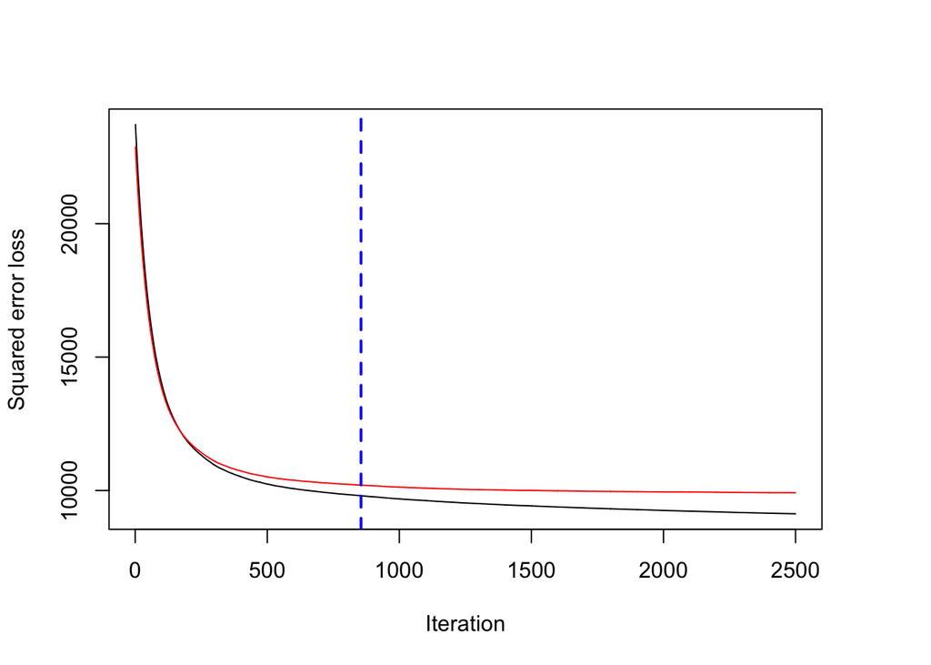

```r
  cat("Optimal number of boosting iterations as determined by the out of bag method :", best.iter_oob)
```

```
## Optimal number of boosting iterations as determined by the out of bag method : 855
```

The following is a plot showing how prediction error on the test data can be expected to change with increasing numbers of boosting iterations. This expected change is determined by using cross-validation within the training set and the model-fitting process.

```r
# # check performance using 5-fold cross-validation
  best.iter <- gbm.perf(gbm1,method="cv")
```

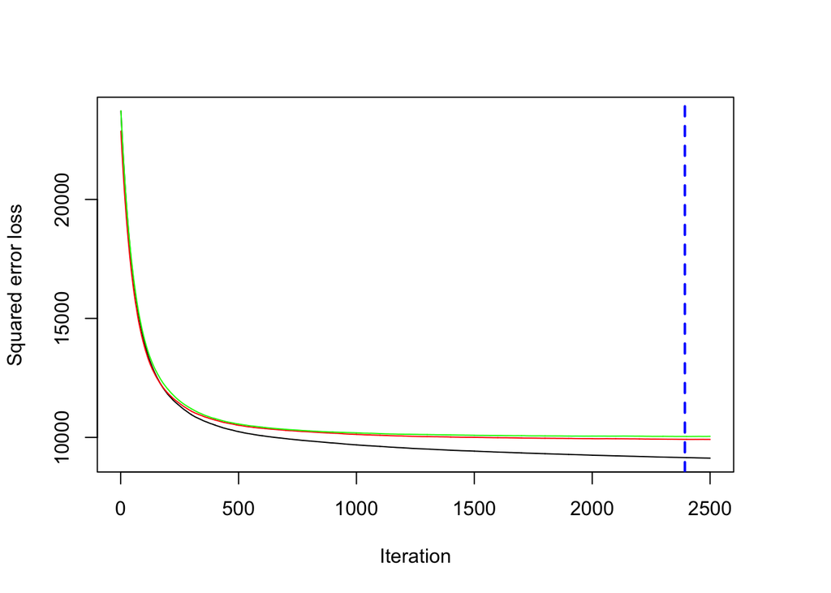

```r
  cat("Optimal number of boosting iterations as determined by cross-validation :", best.iter)
```

```
## Optimal number of boosting iterations as determined by cross-validation : 2393
```

The cross-validation shows that we are unlikely to substantially improve our results on the test set by using  
any more than about 2000 boosting iterations. So I will use “best.iter” iterations when I apply the model to the test data.

```r
# # check performance using a 50% heldout test set
  best.iter_holdout <- gbm.perf(gbm1,method="test")
```

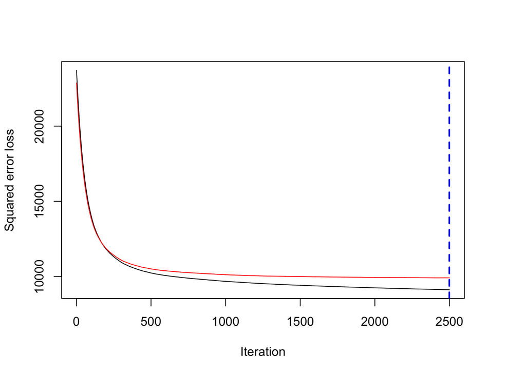

```r
  cat("Best number of iterations as determined by model fitting w/ a holdout set :", best.iter_holdout)
```

```
## Best number of iterations as determined by model fitting w/ a holdout set : 2499
```

The following shows the relative amount of training data variance explained by the 3 covariates.

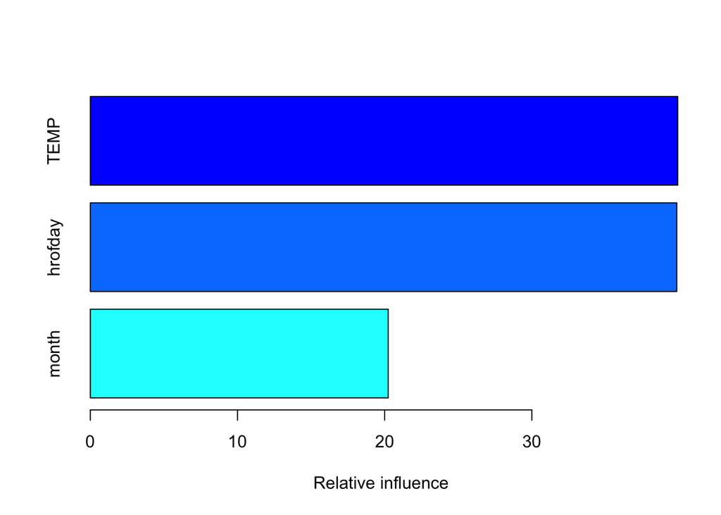

```
##             var  rel.inf
## TEMP       TEMP 39.91255
## hrofday hrofday 39.84685
## month     month 20.24060
```

```r
# plot the performance # plot variable influence
summary(gbm1,n.trees=best.iter) # based on the best number of trees estimated using cross-validation
```

Using the model to predict on both the training data and test data…

```r
# # predict on the new data using "best" number of trees
 f.predict_train <- predict(gbm1, train_data, best.iter)
 f.predict_test <- predict(gbm1,test_data, best.iter)
```

Computing the R-squared on the training set fit, and on the test set…

```r
# R-squared for training data fit and test data fit
residuals_train <- train_data$kwh-f.predict_train
residuals_test <- test_data$kwh-f.predict_test
cat("R-squared for training set", 1-var(residuals_train)/var(train_data$kwh))
```

```
## R-squared for training set 0.5941079
```

```r
cat("R-squared for test set", 1-var(residuals_test)/var(test_data$kwh))
```

```
## R-squared for test set 0.4471652
```

R-squared is improved as compared to the linear regression model, but not greatly. The decrease in R-squared in going from training data to the test data indicates that the model may be slightly overfit. It may be worth trying to apply the model on the test set w/ fewer boosting iterations (which I have done but not shown here, because the results did not improve). The model is not so powerful for several possible reasons. For one, the data is probably somewhat noisy. But more importantly, the features in the model are not so informative. For example, month is a rough approximation for the time of year. The weather in the beginning of March may be very different from the weather in the end of March. The model may work much better if 1-2 more features were added. I suspect that by adding a day of week (1-7) feature, the model would perform much better. I have tested this out as you can see at the end of the project. The result is a much more impressive model. Below is further analysis of the 3-feature model…

Now, I compute the standard error of the GBM model on the test data:

```r
standard_error <- sqrt(var(residuals_test)/length(residuals_test))
cat("The standard error on the test set was :", standard_error)
```

```
## The standard error on the test set was : 1.154367
```

[figure not shown]

```r
hist(residuals, main="Histogram of Test Data Residuals for GBM Model", xlab="Magnitude of Error", ylab="Number of Occurrences" )
```

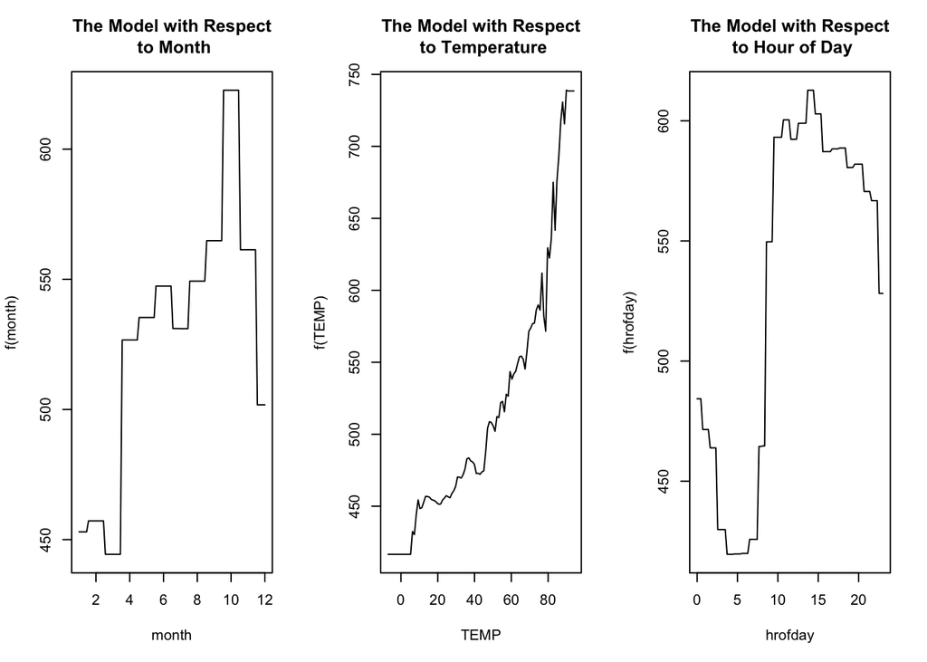

```r
# create marginal plots
# plot variable X1,X2,X3 after "best" iterations
par(mfrow=c(1,3))
plot(gbm1,1,best.iter, main = "The Model with Respect\n to Month")
plot(gbm1,2,best.iter, main = "The Model with Respect\n to Temperature")
plot(gbm1,3,best.iter, main = "The Model with Respect\n to Hour of Day")
```

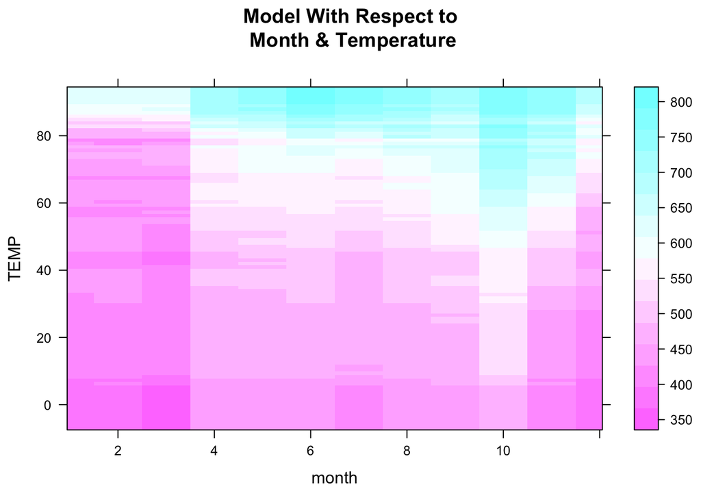

```r
par(mfrow=c(1,3))
#
# #  # contour plot of variables 1 and 2 after "best" number of boosting iterations
plot(gbm1,1:2,best.iter, main = "Model With Respect to\n Month & Temperature")
```

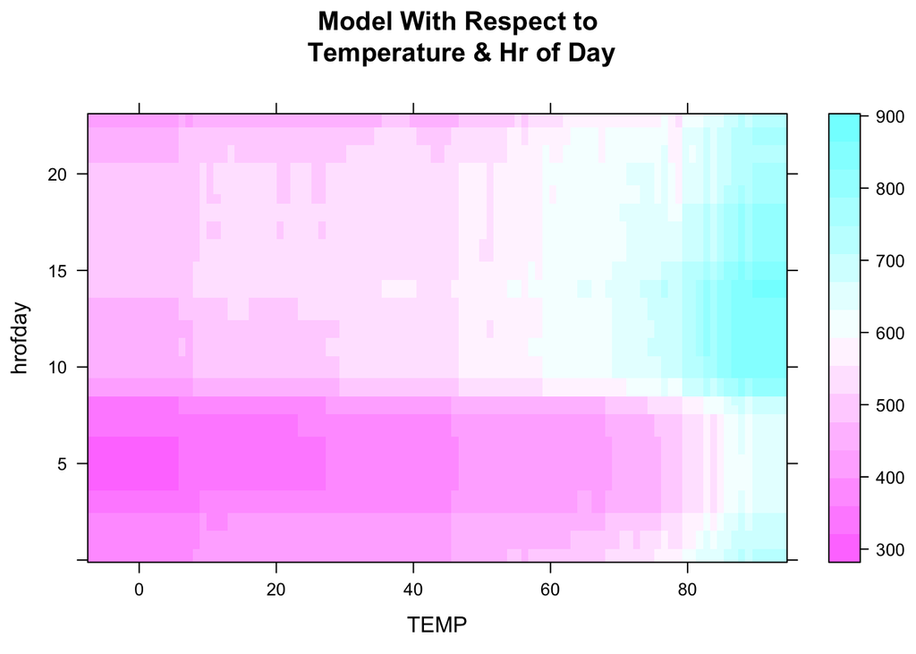

```r
# #  # lattice plot of variables 2 and 3
plot(gbm1,2:3,best.iter, main = "Model With Respect to\n Temperature & Hr of Day")
```

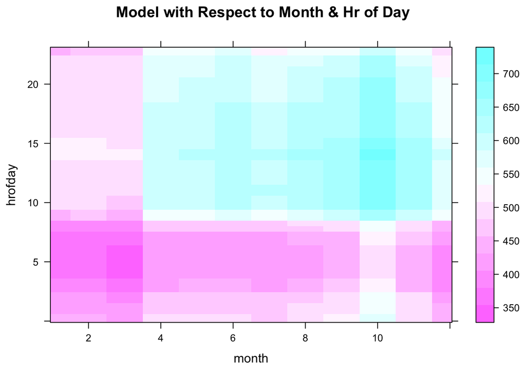

```r
#  # # lattice plot of variables 1 and 3
plot(gbm1, c(1,3), best.iter, main = "Model with Respect to Month & Hr of Day")
```

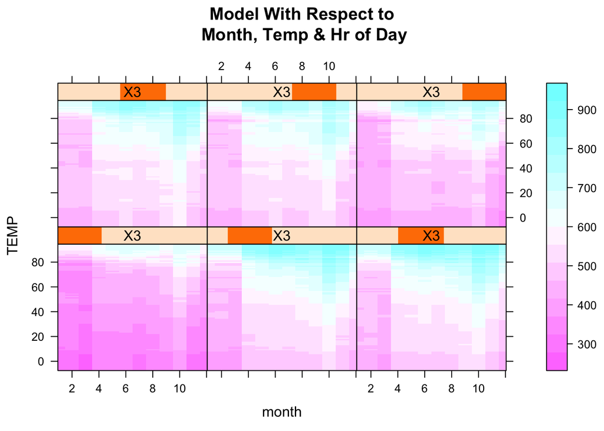

```r
plot(gbm1,1:3,best.iter, main = "Model With Respect to\n Month, Temp & Hr of Day")
```

Lets now compare the predicted model for 2015 with the bill data kwh!

```r
# run your machine learning model and create a data frame of dates, kwh for 1hr interval data for 2015. note you
# may need to include the last few days of 2014 in your dataset due to the billing dates in January (see billdata.xlsx)
# call your data frame pred2015dfd.

# # now for each of the 12 rows in the billsdf, sum the kwh for the date range in each of the rows from pred2015df
# # create a resultsdf which has billdate, predkwh (from pred2015df), actualkwh (from billsdf)
# # display the results

pred2015df <- data.frame(dates=test_data$dates,
                 prediction=f.predict_test)
pred2014df <- data.frame(dates=train_data$dates,
                 prediction=f.predict_train)
pred2015df <- rbind(pred2015df, pred2014df)
pred2015df <- pred2015df[order(pred2015df$dates),]
print(head(pred2015df))
```

```
##                     dates prediction
## 13096 2014-01-01 01:00:00   381.9065
## 16662 2014-01-01 02:00:00   380.8900
## 13245 2014-01-01 03:00:00   342.5935
## 10369 2014-01-01 04:00:00   325.8806
## 16993 2014-01-01 05:00:00   325.8806
## 12828 2014-01-01 06:00:00   323.6149
```

```r
resultsdf <- billdf[, c("billdate", "kwh")]
resultsdf$prediction = 0


for (billrow in 1:nrow(resultsdf)) {
      billperioddf <- pred2015df[with(pred2015df, dates >= billdf$billstartdt[billrow] & dates <=                                      billdf$billenddt[billrow]), ]
      resultsdf$prediction[billrow] <- sum(billperioddf$prediction)
}
print(resultsdf)
```

```
##      billdate   kwh prediction
## 1  2015-01-01 66460   406384.1
## 2  2015-02-01 41180   290635.7
## 3  2015-03-01 48860   274854.4
## 4  2015-04-01 65360   380248.7
## 5  2015-05-01 70020   383542.9
## 6  2015-06-01 86500   442573.3
## 7  2015-07-01 88500   500336.4
## 8  2015-08-01 80240   435565.3
## 9  2015-09-01 81160   469385.2
## 10 2015-10-01 73760   460269.7
## 11 2015-11-01 65740   391742.4
## 12 2015-12-01 64160   419057.9
```

Out of curiosity, it seeems that the GBM model that I tested above could be substantially improved if I added one additional feature. In the following experiment, I have trained and tested a GBM on the same data, but have now added a fourth feature - day of the week (1-7) to the model.

```r
# modeldatadf$dayofyear <-  yday(modeldatadf$dates)
modeldatadf$weekday <-  wday(modeldatadf$dates)
test_data <- subset(modeldatadf, year == 2015) # divide data into training and test subsets
train_data <- subset(modeldatadf, year == 2014)
train_data <- train_data[sample(nrow(train_data)),]  #shuffle/rows of the data for randomization on cross-validation



 gbm1 <-  #fit the model
   gbm(kwh~month+TEMP+hrofday+weekday,         # formula
       data=train_data,    # dataset
       var.monotone=c(0,0,0,0),       #  0: no monotone restrictions
       distribution="gaussian",     # see the help for other choices
       n.trees=2000,                # number of trees
       shrinkage=0.01,              # shrinkage or learning rate,
       interaction.depth=3,
       bag.fraction = 0.5,          # subsampling fraction, 0.5 is probably best
       train.fraction = 0.5,        # fraction of data for training,
       # first train.fraction*N used for training
       n.minobsinnode = 10,         # minimum total weight needed in each node
       cv.folds = 3,                # do 5-fold cross-validation
       keep.data=TRUE,
       verbose=FALSE,
       n.cores=1)
```

The following is a plot showing how the fit on the training data and validation data changes with increased numbers of boosting iterations when cross-validation is used to prevent over-fitting.

```r
# check performance using 5-fold cross-validation
 best.iter <- gbm.perf(gbm1,method="cv")
```

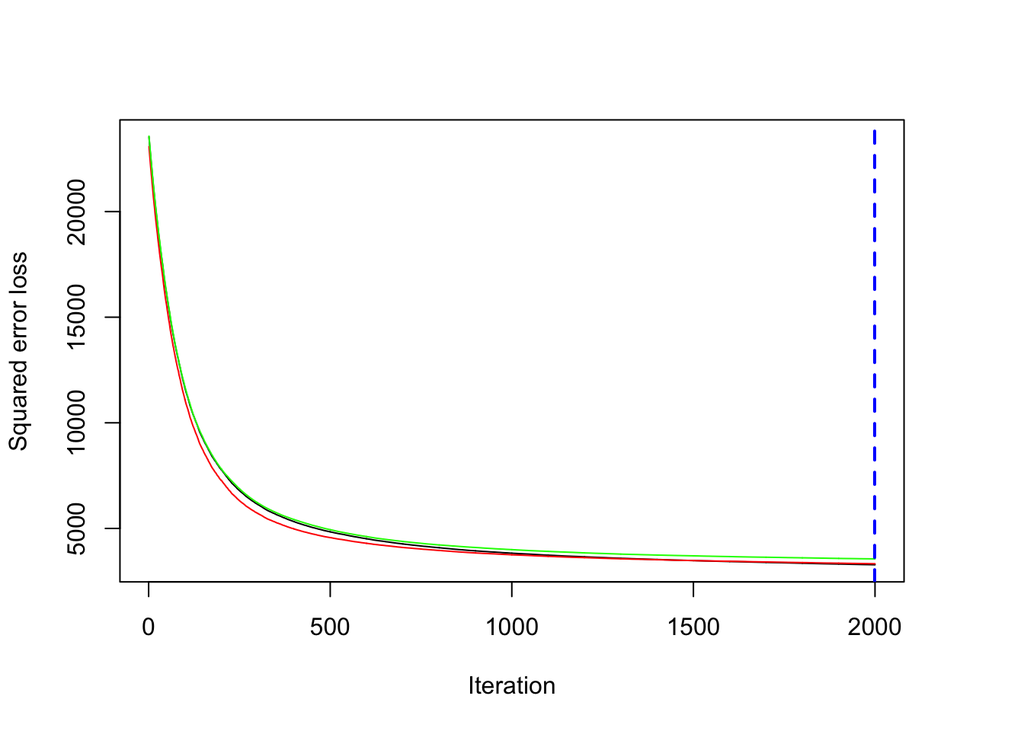

```r
 print(best.iter)
```

```
## [1] 1999
```

The following is a plot of the relative information provided by the variables in the model.

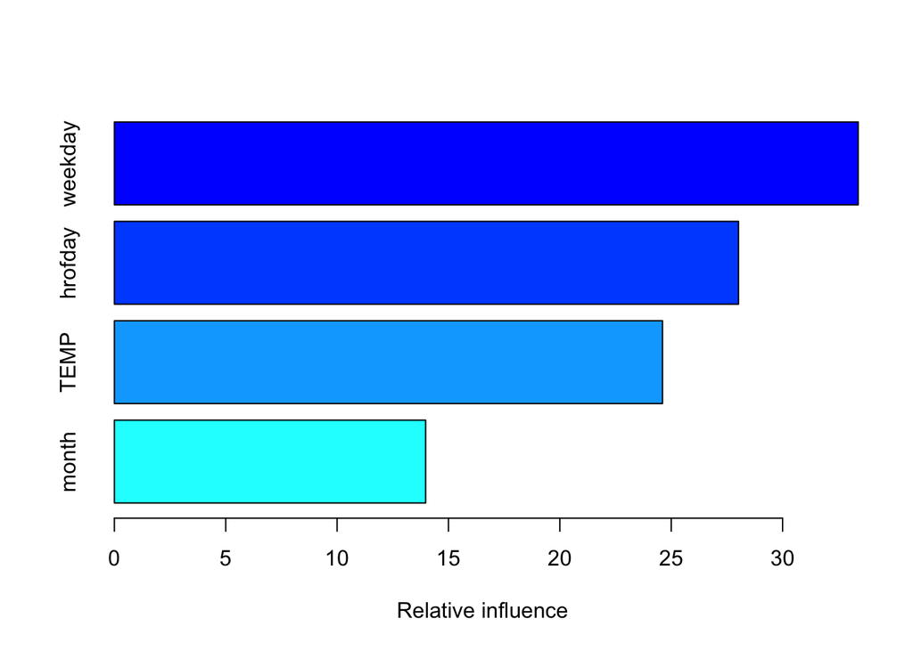

```
##             var  rel.inf
## weekday weekday 33.39507
## hrofday hrofday 28.02112
## TEMP       TEMP 24.60945
## month     month 13.97436
```

```r
# plot the performance # plot variable influence
summary(gbm1,n.trees=best.iter) # based on the estimated best number of trees
```

Now, I make both in sample (2014) predictions and out of sample predictions. I will use the number of iterations that the cross validation method determined to be best.

```r
# predict on the new data using "best" number of trees
f.predict_train <- predict(gbm1, train_data, best.iter)
f.predict_test <- predict(gbm1,test_data, best.iter)
```

Computing the R-squared on the training set fit, and on the test set…

```r
# R-squared for training data fit and test data fit
residuals_train <- train_data$kwh-f.predict_train
residuals_test <- test_data$kwh-f.predict_test
cat("R-squared for training set", 1-var(residuals_train)/var(train_data$kwh))
```

```
## R-squared for training set 0.8594787
```

```r
cat("R-squared for test set", 1-var(residuals_test)/var(test_data$kwh))
```

```
## R-squared for test set 0.7451522
```

R-squared of the 4-feature GBM model is an improvement over the linear regression model and the 3-feature GBM model tested previously. The model may be slightly overfit, meaning that perhaps it could be improved if fewer iterations of boosting were used.

Now, I compute the standard error of the GBM model on the test data:

```r
standard_error <- sqrt(var(residuals_test)/length(residuals_train))

cat("The standard error on the test set was :", standard_error)
```

```
## The standard error on the test set was : 0.7846752
```

[figure not shown]

```r
hist(residuals, main="Histogram of Test Data Residuals for \n 4-Feature GBM Model", xlab="Magnitude of Error", ylab="Number of Occurrences" )
```

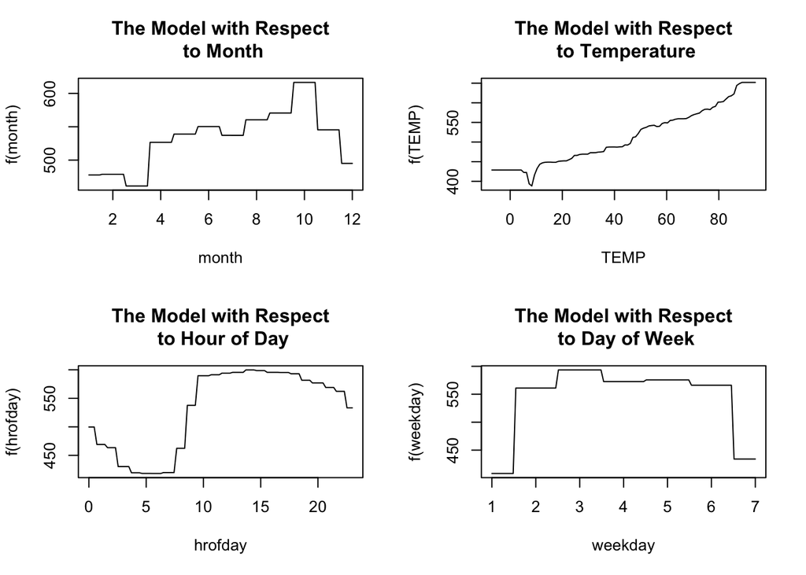

```r
# create marginal plots
# plot variable X1,X2,X3 after "best" iterations
par(mfrow=c(2,2))
plot(gbm1,1,best.iter, main = "The Model with Respect\n to Month")
plot(gbm1,2,best.iter, main = "The Model with Respect\n to Temperature")
plot(gbm1,3,best.iter, main = "The Model with Respect\n to Hour of Day")
plot(gbm1,4,best.iter, main = "The Model with Respect\n to Day of Week")
```

```r
par(mfrow=c(1,1))
#
```

This completes this little exploration of energy load data. Thank You!